# QTM 151 Final Project

## Project Members:

- Joe Van Duyn
- Khushi Goyal
- Andy Wu
- Amber Lin

### In this project, we will answer three different questions about the data in the HRMI dataset, specifically the Economic and Social Rights (ESR) Datasets and the People at Risk Dataset.

# **Insight 1: How does the gender gap in fundamental economic and social rights like access to food vary between low-income and high-income countries, and how has this gap evolved over time?**

```python
# Import packages
import numpy as np
import pandas as pd
import matplotlib.pyplot as plt
from google.colab import files
import io
import seaborn as sns
```

```python
uploaded = files.upload()
esr_dis = pd.read_csv('esr_sex_disaggregated.csv')
```

Upload widget is only available when the cell has been executed in the current browser session. Please rerun this cell to enable.

```
Saving esr_sex_disaggregated.csv to esr_sex_disaggregated.csv
```

```python
# Define the indicators to analyze
indicators = ['HiY_Food', 'LMY_Food']

# Calculate gender gap columns in the full dataset first
for indicator in indicators:
    female_col = f"{indicator}_Female_IAScore"
    male_col = f"{indicator}_Male_IAScore"
    gap_col = f"{indicator}_GenderGap_IAScore"

    esr_dis[gap_col] = esr_dis[female_col] - esr_dis[male_col]

# Filter for 2021 high-income country data
esr_dis_hi = esr_dis[(esr_dis['High_Income_Country'] == 1) & (esr_dis['Year'] == 2021)].copy()

# Store results
gap_results = {}

for indicator in indicators:
    gap_col = f"{indicator}_GenderGap_IAScore"

    df_gap = esr_dis_hi.dropna(subset=[gap_col]).copy()
    df_gap['Average_GenderGap_IA'] = df_gap[gap_col]

    df_sorted = df_gap.sort_values('Average_GenderGap_IA')
    bottom10 = df_sorted.head(10)
    top10 = df_sorted.tail(10)

    gap_results[indicator] = pd.concat([bottom10, top10])
```

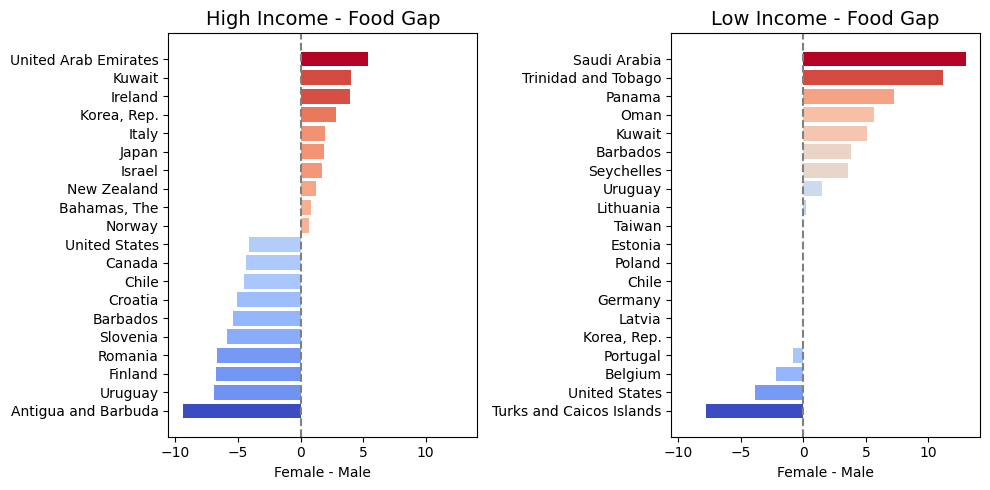

```python
fig, axes = plt.subplots(1, 2, figsize=(10, 5), sharex=True)
axes = axes.flatten()

# Define datasets and titles
datasets = [
    (gap_results['HiY_Food'], 'High Income - Food Gap'),
    (gap_results['LMY_Food'], 'Low Income - Food Gap')
]

# Plot each dataset
for ax, (data, title) in zip(axes, datasets):
    countries = data['Country']
    values = data['Average_GenderGap_IA']
    ax.barh(countries, values, color=plt.cm.coolwarm((values - values.min()) / (values.max() - values.min())))
    ax.axvline(0, color='gray', linestyle='--')
    ax.set_title(title, fontsize=14)
    ax.set_xlabel("Female - Male")
    ax.set_ylabel("")

plt.tight_layout()
plt.show()
```

#### Gender Gaps in Right to Food (IA Scores) -- High-Income Countries

- The bar plots display the top 10 and bottom 10 high-income countries in terms of the gender gap in income-adjusted scored for right to food in 2021.
- A bar to the right of the zero line indicates that females have a higher IA score than males for that right in a given country.
- The largest gender gaps occur in the bottom countries, where males are more favored than females in access to food. We can compare this to low-income countries.